# HW2final_10/10

b03801053公衛四 劉倢如

2017/10/9

```r
H <-  read.csv("HIV.csv", header=TRUE)
A <-  read.csv("AIDS.csv", header=TRUE)
```

```r
#將中文標題命名為英文
names(H)=c("country","diagnostic_year","diagnostic_month","gender","age","case")
names(A)=c("diagnostic_year","diagnostic_month","gender","age","case","country")
```

此資料多數是男生，想看看歷年來(到2016)資料中診斷出HIV病毒的25-34歲且住在台北市的男性人數，感染AIDS的人數分佈趨勢是如何？

```r
library(gridExtra)
#先看資料型態
str(H)
```

```
## 'data.frame':    11062 obs. of  6 variables:
##  $ country         : Factor w/ 23 levels "台中市","台北市",..: 13 2 2 2 22 2 2 7 12 2 ...
##  $ diagnostic_year : int  1984 1984 1984 1984 1984 1984 1984 1984 1984 1985 ...
##  $ diagnostic_month: int  1 10 10 10 10 11 12 12 12 1 ...
##  $ gender          : Factor w/ 2 levels "女","男": 2 2 2 2 2 2 2 2 2 2 ...
##  $ age             : Factor w/ 6 levels "15-24","25-34",..: 1 1 2 3 2 2 2 2 1 1 ...
##  $ case            : int  1 1 1 1 1 1 1 1 1 1 ...
```

```r
str(A)
```

```
## 'data.frame':    7282 obs. of  6 variables:
##  $ diagnostic_year : int  1986 1987 1988 1988 1989 1989 1989 1989 1989 1989 ...
##  $ diagnostic_month: int  2 9 5 10 3 4 8 8 10 10 ...
##  $ gender          : Factor w/ 2 levels "女","男": 2 2 2 2 2 2 2 2 2 2 ...
##  $ age             : Factor w/ 6 levels "15-24","25-34",..: 2 3 2 3 2 4 2 3 2 5 ...
##  $ case            : int  1 1 1 1 2 1 1 1 1 1 ...
##  $ country         : Factor w/ 22 levels "台中市","台北市",..: 2 1 4 16 16 16 11 11 16 16 ...
```

```r
H<-H[1:11009,]
A<-A[1:7240,]
#利用dplyr的select,filter做分類
nh<-select(H,country,diagnostic_year,diagnostic_month,case,age,gender) %>%
  filter(country=="台北市",age=="25-34",gender=="男")
```

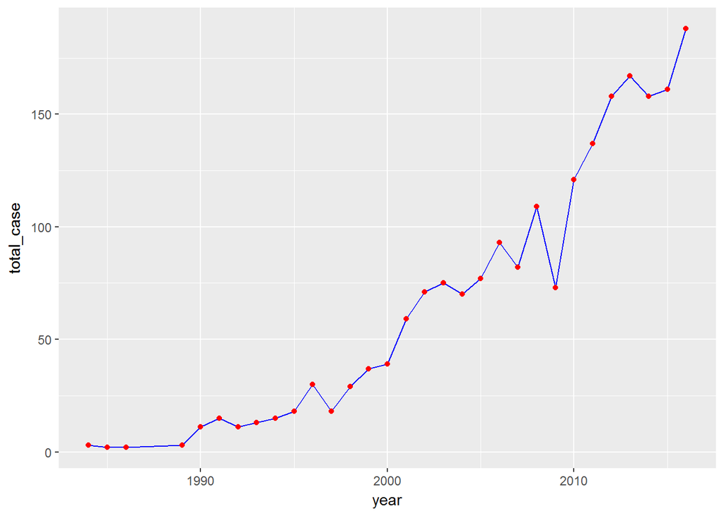

```r
nh1 <- group_by(nh,diagnostic_year) %>%
  summarise(sum(case))
names(nh1) <- c("year","total_case")
w1 <- ggplot(data=nh1,aes(x=year,y=total_case,group=1))+geom_line(colour="blue")+geom_point(colour="red")
w1
```

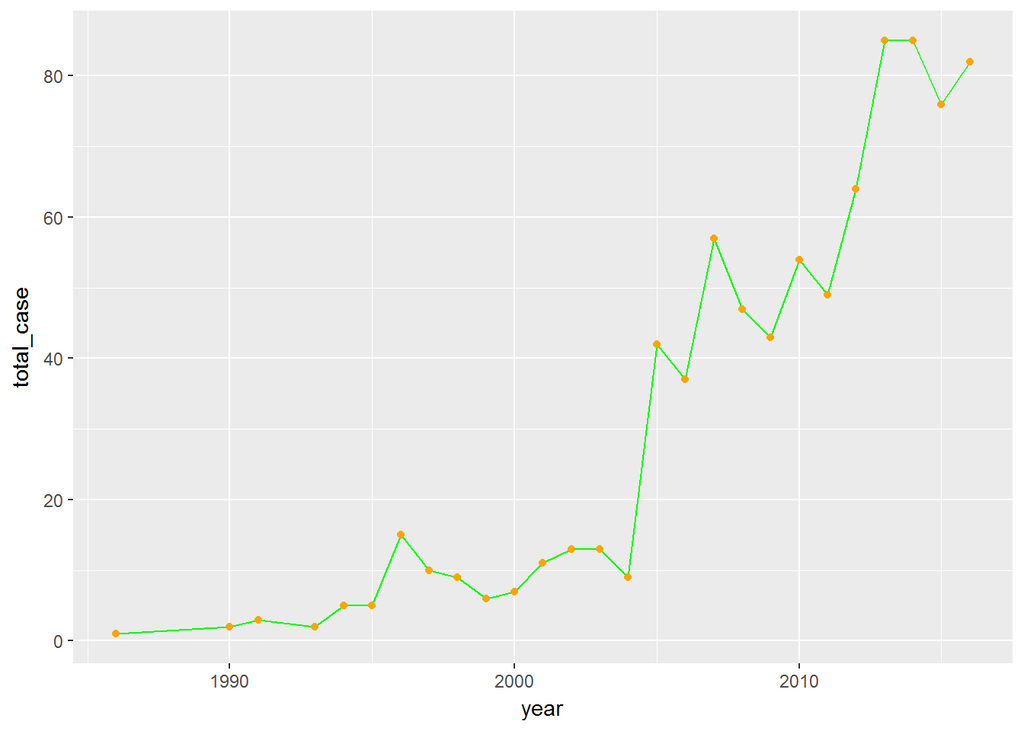

```r
na<-select(A,country,diagnostic_year,case,age,gender) %>%
   filter(country=="台北市",age=="25-34",gender=="男")
na1 <- group_by(na,diagnostic_year) %>%
  summarise(sum(case))
names(na1) <- c("year","total_case")
#畫圖
w2<-ggplot(data=na1,aes(x=year,y=total_case,group=1)) +geom_line(color="green")+geom_point(colour="orange")
w2
```

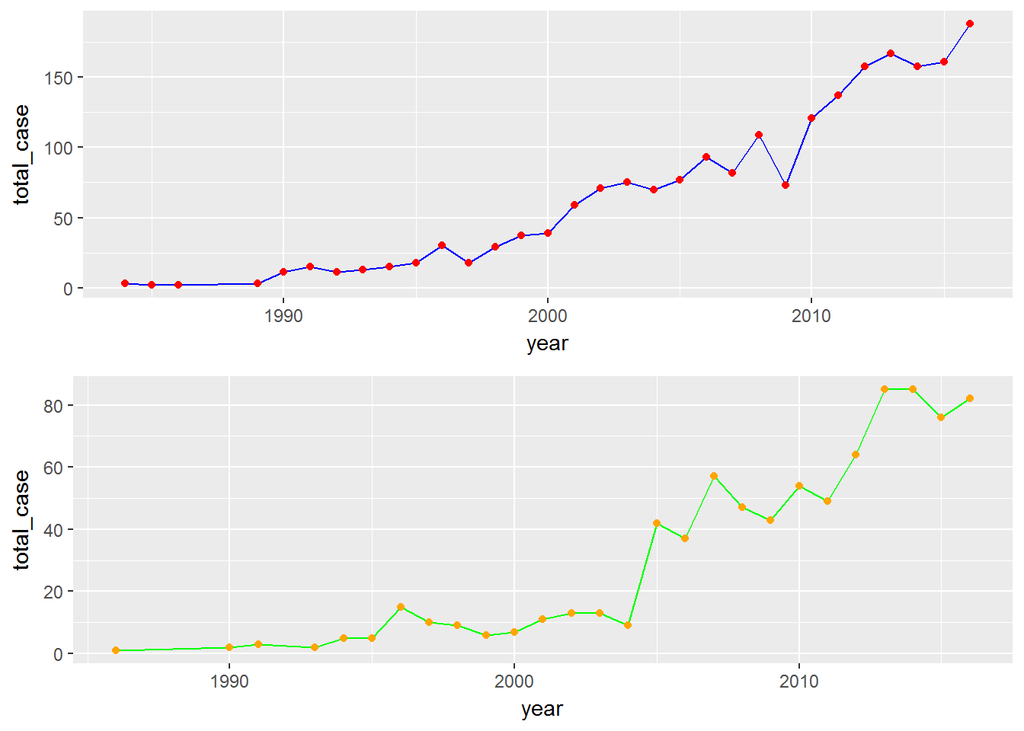

```r
#兩張圖呈現比較
 p=grid.arrange(w1, w2, nrow=2)
```

分析結果發現HIV的走勢圖與AIDS相當相似，幾乎是確診有HIV感染，之後就會有AIDS發病，所以當發現HIV病毒感染後就應該立刻投藥治療，以便追蹤後續的病況，而兩張圖發現，2005年之後，有越來越高的情況

先對有HIV的醫療院所做資料的處理，再把AIDS資料與有AIDS門診服務的醫療院所的資料做整併 利用ggmap分別看2000年與2016年的情況

[figure not shown]

```r
hos <-  read.csv("HIV_HOS.csv", header=TRUE)

names(hos)=c("level","num","name","city_name","address","gpsy","gpsx")
hoss<-hos
hoss$city = substr(hoss$address, 1, 3)
hoss = hoss[,c(6,7,8)]
names(hoss) = c("gpsy", "gpsx","city")
nhoss = hoss %>%
  group_by(city) %>%
  summarise(mean(gpsx), mean(gpsy))

names(nhoss) = c("city","gpsx", "gpsy")


#2000年的分布情況
nac1 = select(A,diagnostic_year,case,country) %>%
  filter(diagnostic_year==2000)
aa <- group_by(nac1,country) %>%
  summarise(sum(case))
names(aa) = c("city","case")
aa$city <- as.character(aa$city)



nn1 <- left_join(aa,nhoss,by = c("city"="city"))

nn1<-nn1[!is.na(nn1$gpsx),]
nn1$case <- as.numeric(nn1$case)


map <- get_map(location = "Taiwan",zoom = 8)
ggmap(map)+geom_point(aes(x = gpsx, y = gpsy,size=case),color="pink",data = nn1)
```

[figure not shown]

```r
#2016年的分布情況
nac = select(A,diagnostic_year,case,country) %>%
  filter(diagnostic_year==2016)
bb <- group_by(nac,country) %>%
  summarise(sum(case))
names(bb) = c("city","case")
bb$city <- as.character(bb$city)


nn <- left_join(bb,nhoss,by = c("city"="city"))

nn<-nn[!is.na(nn$gpsx),]
nn$case <- as.numeric(nn$case)


map <- get_map(location = "Taiwan",zoom = 8)
ggmap(map)+geom_point(aes(x = gpsx, y = gpsy,size=case),color="pink",data = nn)
```

此些愛滋病分布的地區，均有愛滋病治療的醫療院所或藥局，2016年相較於2000年的病例數高出許多，其中又以新北市的病例數最多，高達200多人，而高雄、桃園、台北、台中、台南病例數亦高達100多人，此疾病有都市化趨勢，政府應多加宣導重視此疾病，結合衛教講座，可以先在病例數最多的新北市辦理講座，看看此區人民是否因觀念宣導，而有進一步的行為上的防護措施，進而讓其他地方也跟進

哪一個縣/市是最需要注意AIDS疾病?又AIDS疾病與死亡的分布圖情況如何?

此資料為愛滋病死亡的人數統計

```r
D <-  read.csv("DIE.csv", header=TRUE)

#將中文標題命名為英文

names(D)=c("death_year","death_month","gender","age","case","city")


library(gridExtra)
str(D)
```

```
## 'data.frame':    4110 obs. of  6 variables:
##  $ death_year : int  1986 1988 1988 1988 1988 1989 1989 1989 1989 1989 ...
##  $ death_month: int  3 5 5 10 11 4 4 6 8 10 ...
##  $ gender     : Factor w/ 2 levels "女","男": 2 2 1 2 2 2 2 2 2 2 ...
##  $ age        : Factor w/ 6 levels "15-24","25-34",..: 2 2 3 3 3 2 4 2 3 2 ...
##  $ case       : int  1 1 1 1 1 1 1 1 1 1 ...
##  $ city       : Factor w/ 21 levels "台中市","台北市",..: 2 4 15 15 2 15 15 15 1 11 ...
```

```r
D<-D[1:4103,]
nnd<-select(D,city,death_year,case,age,gender) %>%
  filter(age=="25-34",gender=="男")
nnd1 <- group_by(nnd,city) %>%
  summarise(sum(case))
nnd1$city<-as.character(nnd1$city)
str(nnd1)
```

```
## Classes 'tbl_df', 'tbl' and 'data.frame':    19 obs. of  2 variables:
##  $ city     : chr  "台中市" "台北市" "台東縣" "台南市" ...
##  $ sum(case): int  129 125 7 82 13 29 42 52 12 116 ...
```

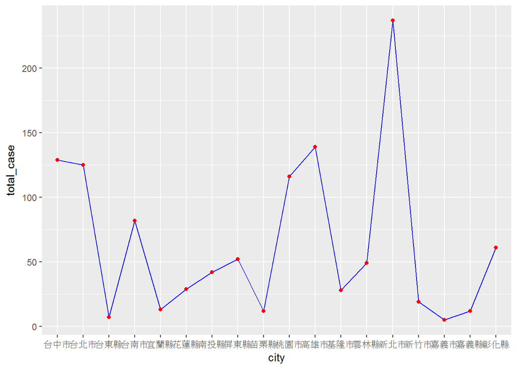

```r
nn1 <- left_join(nnd1,nhoss,by = c("city"="city"))
nn1<-nn1[!is.na(nn1$gpsx),]
names(nn1) <- c("city","total_case","gpsx","gpsy")

nn1<- ggplot(data=nn1,aes(x=city,y=total_case,group=1))+geom_line(colour="blue")+geom_point(colour="red")
nn1
```

沒有用比例來看的原因是，此圖呈現的是歷年來AIDS死亡人數在不同縣市的情況，情況集中最高的地方是在新北市，而回頭看前面ggmap的情況，在2000年時新北市案例不多，但到2016年卻明顯上升，除了觀念的改變，推測可能與都市化也有影響，因為看整體的圖，五大縣市的總人數也都是比較高的

最後，呼應最前面的問題，將AIDS的資料與死亡的人數的圖形比較

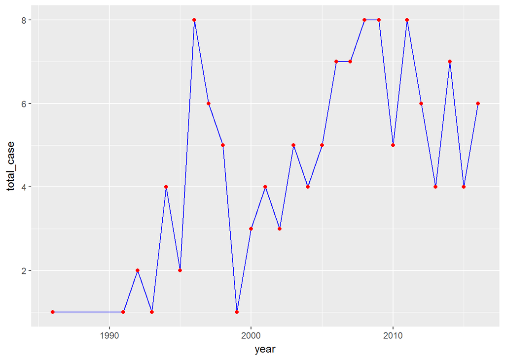

```r
#得到AIDS疾病後與近年來統計死亡的圖形的比較
nd<-select(D,city,death_year,case,age,gender) %>%
  filter(city=="台北市",age=="25-34",gender=="男")
nd1 <- group_by(nd,death_year) %>%
  summarise(sum(case))
names(nd1) <- c("year","total_case")
d1 <- ggplot(data=nd1,aes(x=year,y=total_case,group=1))+geom_line(colour="blue")+geom_point(colour="red")
d1
```

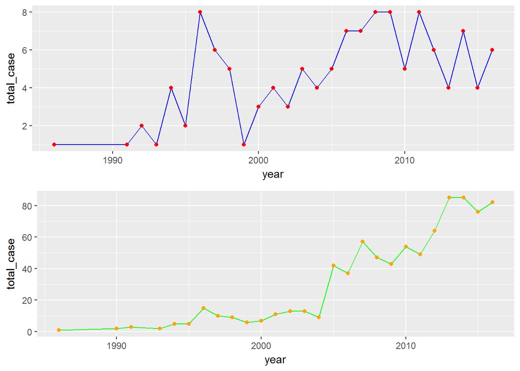

```r
p=grid.arrange(d1, w2, nrow=2)
```

發現台北市25-34男性人口中，AIDS死亡的高峰在1996年，而2010年的前後兩年也是死亡的高峰，對照AIDS的患病人數，在2004年後得到AIDS的人數都比2004年前的人至少高出20,30人